# hw11

Alexis Maldonado

11/27/2023

2.a

```r
library(ISLR2)

Hitters = na.omit(Hitters)
Hitters$Salary = log(Hitters$Salary)
```

2.b

```r
train = Hitters[1:200, ]
test = Hitters[201:nrow(Hitters), ]
```

2.c The final values used for the model were n.trees = 300, interaction.depth = 3, shrinkage = 0.01 and n.minobsinnode = 5.

```r
library(caret)
library(gbm)
formula <- Salary~.
mygrid <- expand.grid(interaction.depth = seq(1, 5, by = 1),
                        n.trees = c(100,200,300),
                        n.minobsinnode = 5,
                        shrinkage = c(0.001,0.01,0.1))
set.seed(100)
gbm_model <- train(formula,
                   data = train,
                   method = "gbm",
                   tuneGrid = mygrid,
                   trControl = trainControl(method = "cv",number=10))
```

2.d In the booested model CAtBat, CRBI, CWalks, and CHits appear to be the most important.

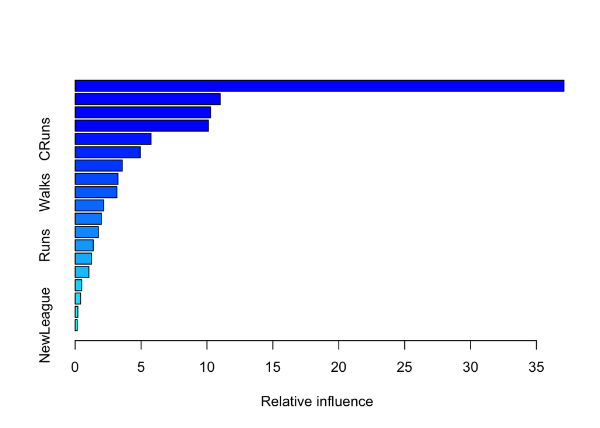

```
##                 var    rel.inf
## CAtBat       CAtBat 37.0913518
## CWalks       CWalks 11.0106911
## CHits         CHits 10.2710078
## CRBI           CRBI 10.1089117
## CRuns         CRuns  5.7553011
## Years         Years  4.9415897
## CHmRun       CHmRun  3.5751554
## AtBat         AtBat  3.2498990
## Walks         Walks  3.1690328
## PutOuts     PutOuts  2.1586405
## RBI             RBI  1.9889568
## Hits           Hits  1.7623789
## Runs           Runs  1.3726577
## Assists     Assists  1.2384963
## Errors       Errors  1.0402024
## HmRun         HmRun  0.4981975
## Division   Division  0.4071054
## League       League  0.2044372
## NewLeague NewLeague  0.1559870
```

```r
boost.Hitters = gbm(Salary~.,data= train, distribution = "gaussian", n.trees=300, interaction.depth = 3, shrinkage = c(0.01))
summary(boost.Hitters)
```

2.e

```r
yhat.boost = predict(boost.Hitters, newdata= train, n.trees=300)
yhat.boost = yhat.boost[1:length(test$Salary)]
mean((yhat.boost- test$Salary)^2)
```

```
## [1] 1.218984
```

2.f 20/3 = ~ 7

```r
library(randomForest)
rf_model = randomForest(Salary ~ ., data = train, ntree = 500, mtry = 7, importance = TRUE )

yhat.rf = predict(rf_model, newdata = test)
print(mean((yhat.rf - test$Salary)^2))
```

```
## [1] 0.2151288
```

.———————————————————

3.a

```r
library(tree)
set.seed(1) # so we all get the same x values.
n = 100
p = 20
all_training_sets = list()
predicted_values <- matrix(NA, nrow = 5, ncol = 1000)

for (j in 1:1000) {
  Xmat = matrix(NA,nrow=n,ncol=p)
  for(i in 1:p){
    Xmat[,i] = rnorm(n)
  }

  beta = rep(seq(1,3,length.out=5),4)
  Y = Xmat%*%beta + rnorm(n,0,1)

  train_set = data.frame(Xmat,Y)
  all_training_sets[[j]] = train_set

  tree_model = tree(Y ~ ., data = train_set)

  if (j <= 5) {
    predicted_values[j, ] = predict(tree_model, newdata = data.frame(matrix(1, nrow = 1, ncol = 20)))
    print(predicted_values[j, 1])
  }
}
```

```
## [1] 14.59419
## [1] 17.08518
## [1] 5.480257
## [1] 14.40228
## [1] 10.36534
```

3.b

```r
(mean(predicted_values) - mean(Y))^2
```

```
## [1] 177.6567
```

```r
mean((predicted_values - mean(predicted_values))^2)
```

```
## [1] 16.55923
```

3.c

```r
library(randomForest)
set.seed(1) # so we all get the same x values.
n = 100
p = 20
all_training_sets = list()
predicted_values2 <- matrix(NA, nrow = 5, ncol = 1000)

for (j in 1:1000) {
  Xmat = matrix(NA,nrow=n,ncol=p)
  for(i in 1:p){
    Xmat[,i] = rnorm(n)
  }

  beta = rep(seq(1,3,length.out=5),4)
  Y = Xmat%*%beta + rnorm(n,0,1)

  train_set = data.frame(Xmat,Y)
  all_training_sets[[j]] = train_set

  rf_model = randomForest(Y ~ ., data = train_set, mtry = 10, ntree = 200)

  if (j <= 5) {
    predicted_values2[j, ] = predict(rf_model, newdata = data.frame(matrix(1, nrow = 1, ncol = 20)))
    print(predicted_values2[j, 1])
  }
}
```

```
## [1] 12.4918
## [1] 11.93545
## [1] 11.21848
## [1] 16.48158
## [1] 13.94433
```

3.d

```r
(mean(predicted_values2) - mean(Y))^2
```

```
## [1] 194.7317
```

```r
mean((predicted_values2 - mean(predicted_values2))^2)
```

```
## [1] 3.469766
```

3.e We have an increase in order of magnitude of 177 to 200

3.f We have a dencrease in order of magnitude of 16 to 3.

3.g We can see the increasing the bias does lead to a decrease in variance. We see that the random forest tree has alot less variance compared to the single tree.

.———————————————————

4.a

4.b For each iteration we have the observations closest to their cluster become part of the cluster meaning that each point is the closest it can be to its ‘kind’ causing there to be less varation since farther observations would not be choosen.

4.c i.

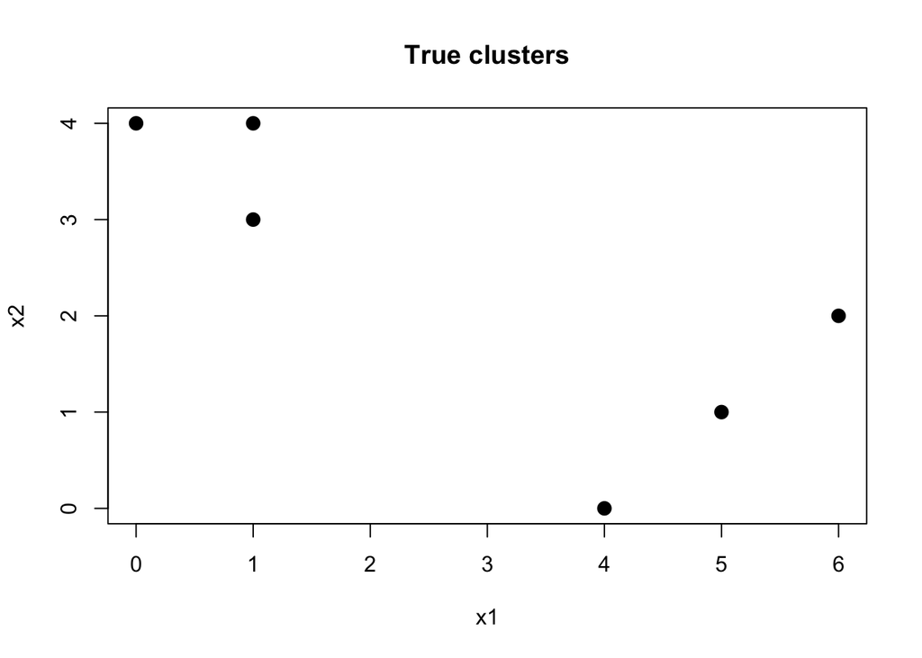

```r
x1 = c(1, 1, 0, 5, 6, 4)
x2 = c(4, 3, 4, 1, 2, 0)
plot(x1, x2,
     main = "True clusters", xlab = "x1", ylab = "x2", pch = 20, cex = 2)
```

```r
set.seed(10)
cl = sample(2, 6, replace = T)
cl
```

```
## [1] 1 1 2 2 2 1
```

3. c1 = 1/3(1+1+4) = 2 (x1) 1/3(4+3+0) = 2 1/3 (x2)

c2 = 1/3(0+5=6) = 3 2/3 (x1) 1/3(4+1+2) = 2 1/3 (x2)

4. Cluster 1 would have obs. 1, 2, and 3 Cluster 2 would have obs. 4, 5, and 6
5. c1 = 1/3(1+1+0) = 2/3 (x1) 1/3(4+3+4) = 3 2/3 (x2)

c2 = 1/3(5+6+4) = 5 (x1) 1/3(1+2+0) = 1 (x2) I believe mine should not change anymore after calculating the new centroids.

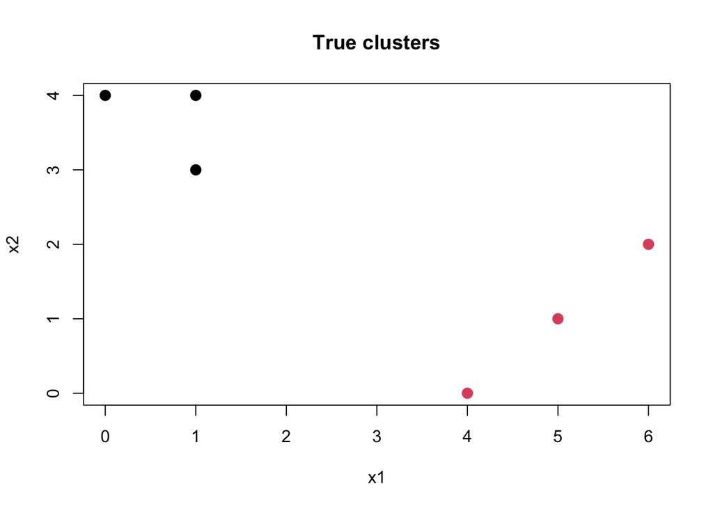

```r
cl2 = c(1,1,1,2,2,2)
plot(x1, x2, col = cl2,
     main = "True clusters", xlab = "x1", ylab = "x2", pch = 20, cex = 2)
```

.———————————————————

5.a

```r
library("dendextend")
```

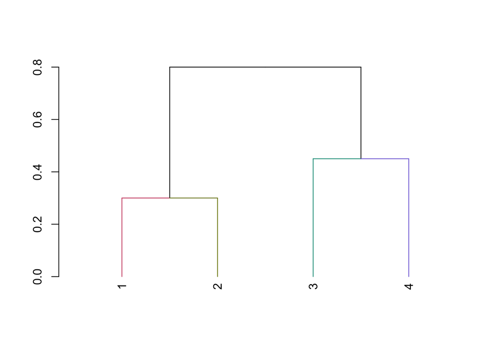

```r
distM = as.dist(matrix(c(0, 0.3, 0.4, 0.7, 0.3, 0, 0.5, 0.8, 0.4, 0.5, 0.0, 0.45, 0.7, 0.8, 0.45, 0.0), nrow = 4))
dendro = as.dendrogram(hclust(distM, method = "complete"))
dendo = color_branches(dendro,k=4)
plot(dendo)
```

5.b

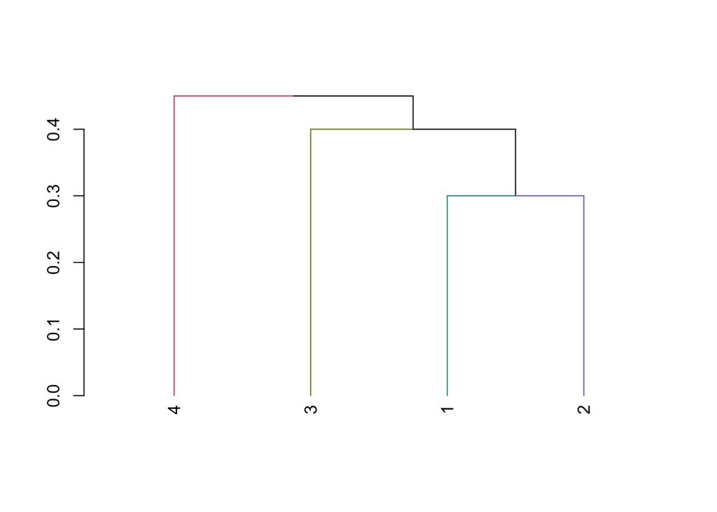

```r
dendro_single = as.dendrogram(hclust(distM, method = "single"))
dendro_single = color_branches(dendro_single,k=4)
plot(dendro_single)
```

5.c If you were to make a single cut in A we would get two clusters 1 and 2 would be a cluster and 3 and 4 would be another cluster

5.d If you were to make a single cut in B we would get two clusters 1, 2, and 3 would be a cluster and 4 alone would be another cluste.